# R_template and tutorial

## 1. Trim variables

```r
# eliminating first unnecessary columns
v <- dplyr::select(v,-StartDate,-EndDate,-Status,-IPAddress,-Progress,-RecordedDate,-ResponseId,-RecipientLastName,-RecipientFirstName,-RecipientEmail,-ExternalReference,-LocationLatitude,-LocationLongitude,-DistributionChannel,-UserLanguage,-Q1,-Q12_1, -Q12_2, -Q12_3, -Q12_4, -Q12_5, -Q12_6, -Q12_7)
print(paste("Raw data: N=",nrow(v),'and',ncol(v),'variables'))
```

[output not shown]

## 2. Add participant ID's

```r
v$ID <- c(1:length(v$Age)) # Status = dataframe length
v$PID <- paste("S",v$ID,sep="")
v$PID<-factor(v$PID)
ind<-colnames(v)!='ID'
v <- v[, ind]  ## Delete ID and just retain PID
```

## 3. Convert categorical variables into explicit Factors

```r
v$Gender <- factor(v$Gender,levels=c(1,2,3),labels = c('Male','Female','Other'))
v$MusicalExpertise <- factor(v$MusicalExpertise,levels = c(1,2,3,4,5,6),labels = c("NonMusician","Music-Loving NonMusician","Amateur","Serious Amateur Musician","Semi-Pro","Pro"))
v$MusicalExpertiseBinary<-factor(v$MusicalExpertise,levels = levels(v$MusicalExpertise),labels=c('Nonmusician','Nonmusician','Musician','Musician','Musician','Musician'))
```

### Recode instruments (2): Eliminate incomplete

Here we first created a row to identify the NAs (missing values) in the dataset, afterwards we created a threshold of 95% completion rate. If participants completed more than 95% of the survey, we keep them.

```r
v$NAS <- rowSums(is.na(v[, 11:108]))
NAS <- 100 - (v$NAS/nrow(v))*100
threshold <- 95
good_ones <- NAS >= threshold
v <- v[good_ones, ]
v <- v[,1:110] # drop NAS
print(paste('Trimmed data: N=',nrow(v)))
```

```
[1] "Trimmed data: N= 91"
```

```r
head(v)
```

```
  Time Finished Age Gender Country         MusicalExpertise PreferredGenre
1  628        1  26 Female     107 Serious Amateur Musician      Classical
2 2700        1  22   Male     185              NonMusician      Indie Pop
3  922        1  55 Female     185                      Pro      Classical
4  792        1  29 Female     107 Music-Loving NonMusician            Pop
5 5963        1  26 Female       9                 Semi-Pro            pop
6 1500        1  36   Male     185 Music-Loving NonMusician      Indie pop
  InstrumentPlayer                   Instrument MusicalTraining OG_01_SADNESS
1               35                        Piano              13             6
2               36                                                          6
3               35 Piano, flute, voice, violin               50             5
4               36                                                          4
5               35                        piano              22             6
6               36                                                          5
  OG_01_CALMNESS OG_01_JOY OG_01_ANGER OG_01_FEAR OG_01_POWER OG_01_SURPRISE
```

[output cut: 118 more lines]

### Recode instruments (3): Convert into long-format

## 5. Convert into long-format

```r
df <- melt(v,id.vars = c("PID","Age","Gender","Country","MusicalExpertise", "Time", "Finished", "PreferredGenre", "InstrumentPlayer", "Instrument", "MusicalTraining", "MusicalExpertiseBinary"))
df$Track<-df$variable
df$Track <- gsub("[A-Z][A-Z]_", "", df$Track) #function to substitute every "_POWER" with "" in df$variable
df$Track <- gsub("_[A-Z]+$", "", df$Track) #function to substitute every "_POWER" with "" in df$variable

df$Source <- gsub("_[0-9][0-9]_[A-Z]+$", "", df$variable) # take out source (OG and PTs ie own vs participant generated)
df$Scale <- gsub("[A-Z][A-Z]_[0-9][0-9]_", "", df$variable) # take out scale

df$Track<-factor(df$Track,levels = c('01','02','03','04','05','06','07'),labels = c('Sadness','Joy','Calmness','Anger','Fear','Power','Surprise'))
df$Source<-factor(df$Source,levels = c('OG','PT'),labels = c('Exp1','Exp2'))

colnames(df)[colnames(df)=='value']<-'Rating'
df$Rating <- dplyr::recode(df$Rating, `1` = 1L, `3` = 2L, '4' = 3L, '5' = 4L, '6' = 5L) #  "1" = "1", "3" = "2", "4" = "3", "5"="4", "6" = "5
df$Scale<-factor(df$Scale)
df$PreferredGenre<-factor(df$PreferredGenre)
```

## 6. Drop unnecessary variables

```r
df <- dplyr::select(df,-Country,-Finished,-InstrumentPlayer,-Instrument,-MusicalTraining,-variable,-MusicalExpertise,-PreferredGenre)
head(df)
```

```
  PID Age Gender Time MusicalExpertiseBinary Rating   Track Source   Scale
1  S1  26 Female  628               Musician      5 Sadness   Exp1 SADNESS
2  S2  22   Male 2700            Nonmusician      5 Sadness   Exp1 SADNESS
3  S3  55 Female  922               Musician      4 Sadness   Exp1 SADNESS
4  S4  29 Female  792            Nonmusician      3 Sadness   Exp1 SADNESS
5  S5  26 Female 5963               Musician      5 Sadness   Exp1 SADNESS
6  S6  36   Male 1500            Nonmusician      4 Sadness   Exp1 SADNESS
```

### Munging done

After the munging, it is prudent to check various aspects of the data.

## 1. Show us the descriptives

such as the N, age, gender are echoed in order to remind us of the dataset properties (`demographics_info.R`).

```r
source('scr/demographics_info.R')     # Reports N, Age and other details
```

```
[1] "N = 91"
[1] "Mean age 34.99"
[1] "SD age 15.86"
[1] "Youngest 18 years"
[1] "Oldest 71 years"

  Male Female  Other
    23     67      1

             NonMusician Music-Loving NonMusician                  Amateur
                      13                       44                       15
Serious Amateur Musician                 Semi-Pro                      Pro
                      11                        6                        2

Nonmusician    Musician
         57          34
```

## 2. Data consistency

We can also explore the consistency of the ratings across the people to check whether people agreed on the ratings and generally understood the task (`interrater_reliability.R`).

```r
source('scr/interrater_reliability.R')# Quality checks, consistency check
```

```
[1] "Fastest response 7.17 mins"
[1] "Slowest response 8291.48 mins"
[1] "Median response 14.9 mins"
```

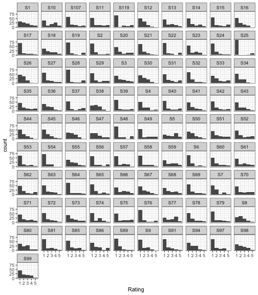

```
Table: Inter-reliability ratings (Cronbach alphas)

| SADNESS| CALMNESS|   JOY| ANGER| FEAR| POWER| SURPRISE|
|-------:|--------:|-----:|-----:|----:|-----:|--------:|
|   0.995|    0.994| 0.995|  0.99| 0.99| 0.962|    0.978|
```

## 3. Data distributions

We also want to look at the distributions of the collected data in order to learn whether one needs to use certain operations (transformations or resort to non-parametric statistics) in the subsequent analyses (`visualise.R`). This step will also include displaying correlations between the emotion scales which is a useful operation to learn about the overlap of the concepts used in the tasks.

```r
source('scr/visualise.R')             # Visualise few aspects of the data
```

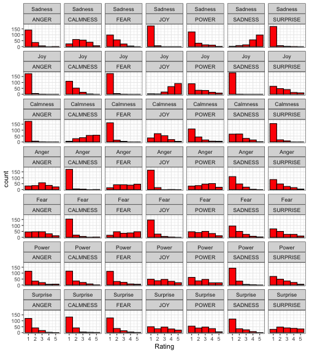

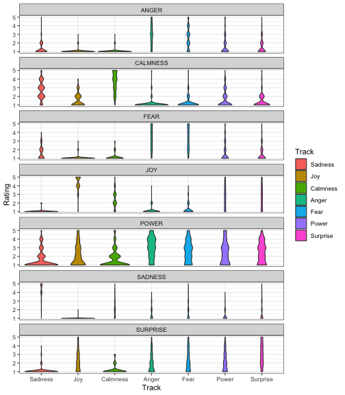

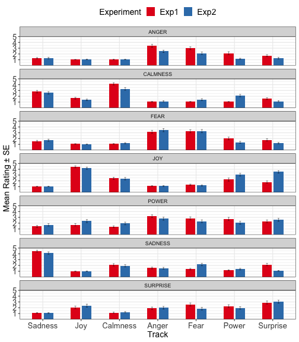

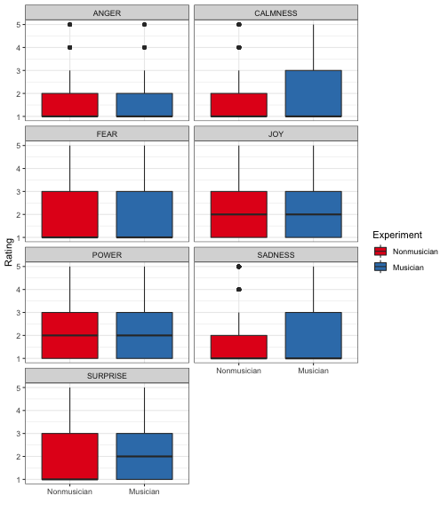

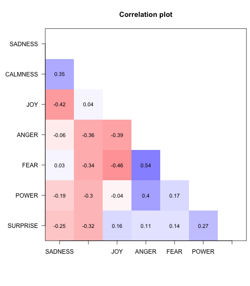

### Conclusion

- We now have mastered the difficult part